# Multivariate Models HW Assignment

Hannah Houston and Ansley Williamson

19 Feb 2023

For this assignment will be analyzing data on the Vegetation and Environment in Dutch Dune Meadows.

To import the data and read the metadata run the following:

```r
library(vegan)
data(dune)
data(dune.env)
?dune
```

1. Conduct an indirect ordination on the dune plant community. Specifically, visually examine a NMDS plot using the bray-curtis distance metric. Below is some code to help you develop a potential plot that emphasizes the role of the environmental variable “Moisture”. Describe how you interpret the graphic. What is the goal of creating such a plot? Does this analysis suggest any interesting findings with respect to the dune vegetation?

```r
#make the nmds model
#remember:
  #NMDS Maximizes rank-order correlation between distance measures and distance in ordination        #space. Points are moved to minimize “stress”. Stress is a measure of the mismatch between the     #two kinds of distance indirect, so only a single matrix is analyzed
  #bray-curtis is default distance metric
dune_mds <- metaMDS(dune, distance = "bray")
```

```
## *** Best solution repeated 8 times
```

[figure not shown]

[output not shown]

```r
#just for fun
stressplot(dune_mds) #shows goodness of fit of the model, close to the line = low stress value
```

How to interpret the graphic: The axes on this plot are meaningless. The distance between points represents the similarity or dissimilarity between points (plant species) for the metric observed (moisture). Points that are closer together have similar moisture requirements than points far from each other.

Goal of creating plot: To observe similarities and differences in moisture requirements for dune species in a two dimensional space.

Findings with respect to dune vegetation: There are two distinct clusters of points, indicating that there are two distinct groups of vegetation that have similar moisture requirements with a healthy spectrum of species between them. It appears as though airaprae, empenigr, and hyporadi are outliers and the model might be improved by throwing out those data points.

2. Carry out a direct ordination using CCA in order to test any potential hypotheses that you developed after examining the MDS plot. Specifically, carry out a test of the entire model (i.e., including all constrained axes) and also carry out tests at the scale of individual explanatory variables you included in your model if you included more than one variable. Plot your results.

```r
#test of entire model
  #remember: variables are A1 (measure of soil thickness), moisture, management, use, and manure
cca_dune <- cca(dune ~ ., data=dune.env)
RsquareAdj(cca_dune, 100)
```

```
## $r.squared
## [1] 0.7106267
##
## $adj.r.squared
## [1] 0.223874
```

```r
anova(cca_dune, permutations = 999)
```

```
## Permutation test for cca under reduced model
## Permutation: free
## Number of permutations: 999
##
## Model: cca(formula = dune ~ A1 + Moisture + Management + Use + Manure, data = dune.env)
##          Df ChiSquare      F Pr(>F)
## Model    12    1.5032 1.4325  0.033 *
## Residual  7    0.6121
## ---
## Signif. codes:  0 '***' 0.001 '**' 0.01 '*' 0.05 '.' 0.1 ' ' 1
```

```r
anova(cca_dune, by='margin', permutations = 999)
```

```
## Permutation test for cca under reduced model
## Marginal effects of terms
## Permutation: free
## Number of permutations: 999
##
## Model: cca(formula = dune ~ A1 + Moisture + Management + Use + Manure, data = dune.env)
##            Df ChiSquare      F Pr(>F)
## A1          1   0.11070 1.2660  0.235
## Moisture    3   0.31587 1.2041  0.250
## Management  2   0.15882 0.9081  0.575
## Use         2   0.13010 0.7439  0.798
## Manure      3   0.25490 0.9717  0.493
## Residual    7   0.61210
```

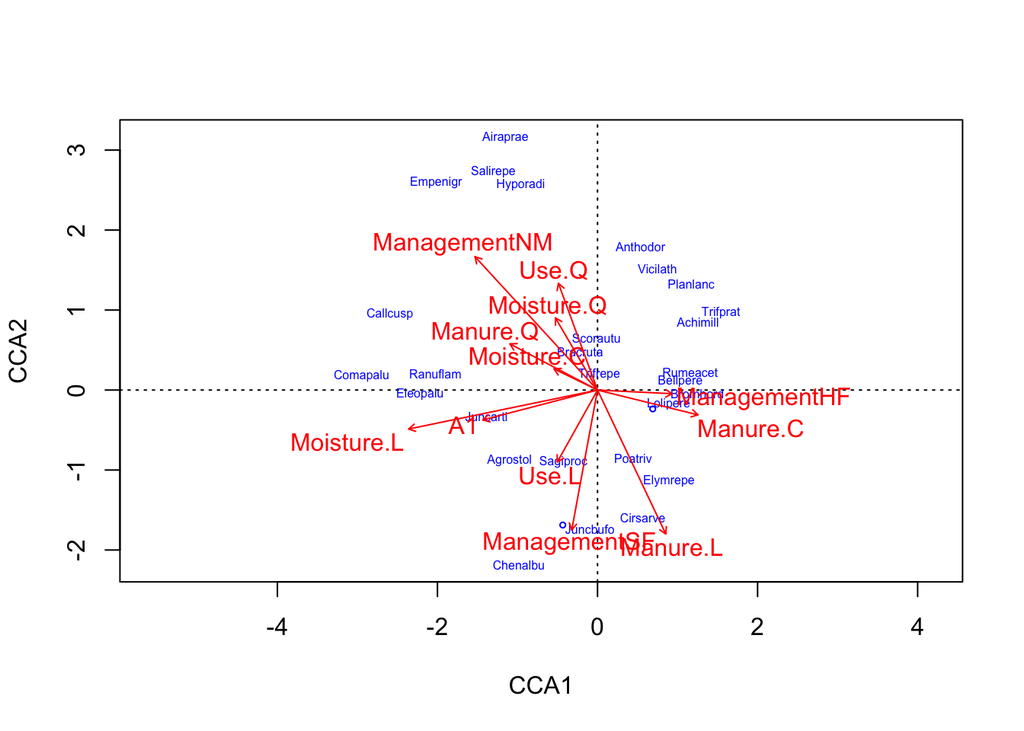

```r
plot(cca_dune, type='n', scaling=1)
orditorp(cca_dune, display='sp', cex=0.5, scaling=1, col='blue')
text(cca_dune, display='bp', col='red')
```

```r
#test of individual explanatory variables: A1
cca_dune_A1 <- cca(dune ~ A1, data=dune.env)
RsquareAdj(cca_dune_A1, 100)
```

```
## $r.squared
## [1] 0.1062564
##
## $adj.r.squared
## [1] 0.05524049
```

```r
anova(cca_dune_A1, permutations = 999)
```

```
## Permutation test for cca under reduced model
## Permutation: free
## Number of permutations: 999
##
## Model: cca(formula = dune ~ A1, data = dune.env)
##          Df ChiSquare    F Pr(>F)
## Model     1   0.22476 2.14  0.026 *
## Residual 18   1.89050
## ---
## Signif. codes:  0 '***' 0.001 '**' 0.01 '*' 0.05 '.' 0.1 ' ' 1
```

```r
anova(cca_dune_A1, by='margin', permutations = 999)
```

```
## Permutation test for cca under reduced model
## Marginal effects of terms
## Permutation: free
## Number of permutations: 999
##
## Model: cca(formula = dune ~ A1, data = dune.env)
##          Df ChiSquare    F Pr(>F)
## A1        1   0.22476 2.14  0.029 *
## Residual 18   1.89050
## ---
## Signif. codes:  0 '***' 0.001 '**' 0.01 '*' 0.05 '.' 0.1 ' ' 1
```

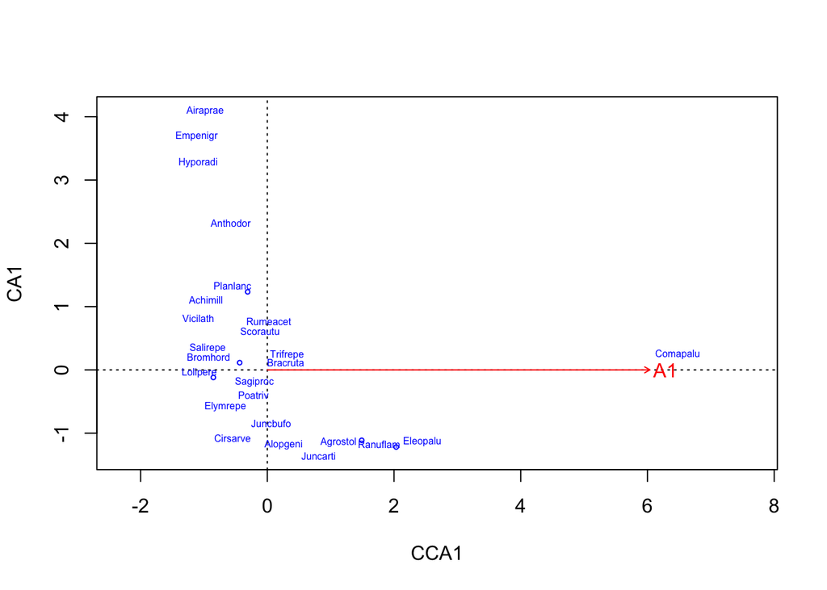

```r
plot(cca_dune_A1, type='n', scaling=1)
orditorp(cca_dune_A1, display='sp', cex=0.5, scaling=1, col='blue')
text(cca_dune_A1, display='bp', col='red')
```

```r
#test of individual explanatory variables: Moisture
cca_dune_moist <- cca(dune ~ Moisture, data=dune.env)
RsquareAdj(cca_dune_moist, 100)
```

```
## $r.squared
## [1] 0.2970359
##
## $adj.r.squared
## [1] 0.1691953
```

```r
anova(cca_dune_moist, permutations = 999)
```

```
## Permutation test for cca under reduced model
## Permutation: free
## Number of permutations: 999
##
## Model: cca(formula = dune ~ Moisture, data = dune.env)
##          Df ChiSquare      F Pr(>F)
## Model     3   0.62831 2.2536  0.001 ***
## Residual 16   1.48695
## ---
## Signif. codes:  0 '***' 0.001 '**' 0.01 '*' 0.05 '.' 0.1 ' ' 1
```

```r
anova(cca_dune_moist, by='margin', permutations = 999)
```

```
## Permutation test for cca under reduced model
## Marginal effects of terms
## Permutation: free
## Number of permutations: 999
##
## Model: cca(formula = dune ~ Moisture, data = dune.env)
##          Df ChiSquare      F Pr(>F)
## Moisture  3   0.62831 2.2536  0.002 **
## Residual 16   1.48695
## ---
## Signif. codes:  0 '***' 0.001 '**' 0.01 '*' 0.05 '.' 0.1 ' ' 1
```

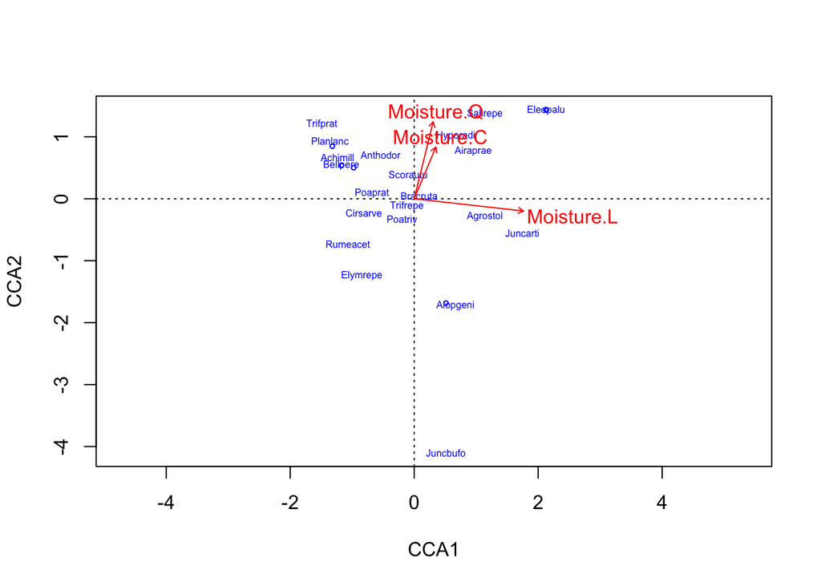

```r
plot(cca_dune_moist, type='n', scaling=1)
orditorp(cca_dune_moist, display='sp', cex=0.5, scaling=1, col='blue')
text(cca_dune_moist, display='bp', col='red')
```

```r
#test of individual explanatory variables: Management
cca_dune_mgmt <- cca(dune ~ Management, data=dune.env)
RsquareAdj(cca_dune_mgmt, 100)
```

```
## $r.squared
## [1] 0.285467
##
## $adj.r.squared
## [1] 0.1552457
```

```r
anova(cca_dune_mgmt, permutations = 999)
```

```
## Permutation test for cca under reduced model
## Permutation: free
## Number of permutations: 999
##
## Model: cca(formula = dune ~ Management, data = dune.env)
##          Df ChiSquare      F Pr(>F)
## Model     3   0.60384 2.1307  0.003 **
## Residual 16   1.51143
## ---
## Signif. codes:  0 '***' 0.001 '**' 0.01 '*' 0.05 '.' 0.1 ' ' 1
```

```r
anova(cca_dune_mgmt, by='margin', permutations = 999)
```

```
## Permutation test for cca under reduced model
## Marginal effects of terms
## Permutation: free
## Number of permutations: 999
##
## Model: cca(formula = dune ~ Management, data = dune.env)
##            Df ChiSquare      F Pr(>F)
## Management  3   0.60384 2.1307  0.003 **
## Residual   16   1.51143
## ---
## Signif. codes:  0 '***' 0.001 '**' 0.01 '*' 0.05 '.' 0.1 ' ' 1
```

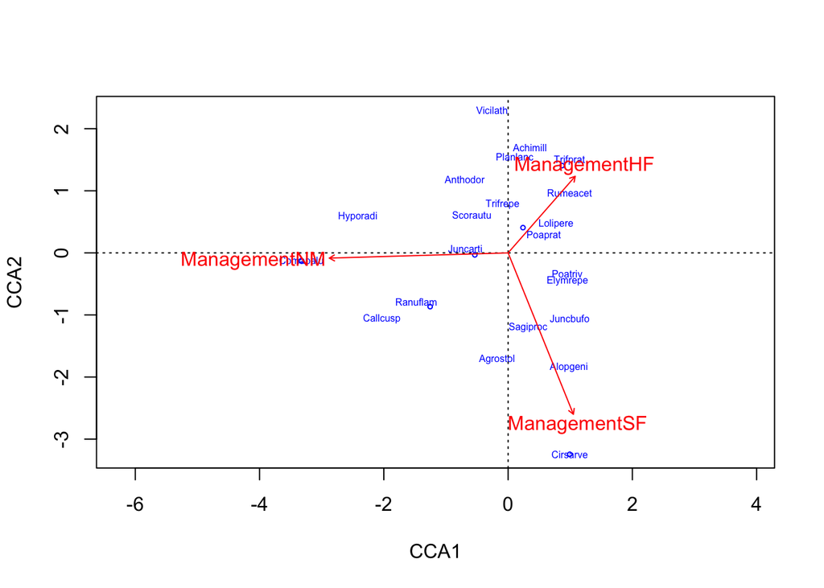

```r
plot(cca_dune_mgmt, type='n', scaling=1)
orditorp(cca_dune_mgmt, display='sp', cex=0.5, scaling=1, col='blue')
text(cca_dune_mgmt, display='bp', col='red')
```

```r
#test of individual explanatory variables: Use
cca_dune_use <- cca(dune ~ Use, data=dune.env)
RsquareAdj(cca_dune_use, 100)
```

```
## $r.squared
## [1] 0.1185381
##
## $adj.r.squared
## [1] 0.005695307
```

```r
anova(cca_dune_use, permutations = 999)
```

```
## Permutation test for cca under reduced model
## Permutation: free
## Number of permutations: 999
##
## Model: cca(formula = dune ~ Use, data = dune.env)
##          Df ChiSquare      F Pr(>F)
## Model     2   0.25074 1.1431  0.302
## Residual 17   1.86452
```

```r
anova(cca_dune_use, by='margin', permutations = 999)
```

```
## Permutation test for cca under reduced model
## Marginal effects of terms
## Permutation: free
## Number of permutations: 999
##
## Model: cca(formula = dune ~ Use, data = dune.env)
##          Df ChiSquare      F Pr(>F)
## Use       2   0.25074 1.1431  0.297
## Residual 17   1.86452
```

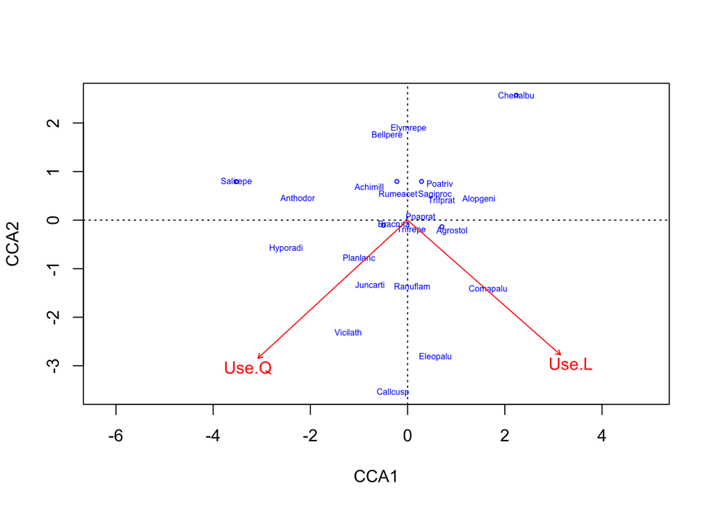

```r
plot(cca_dune_use, type='n', scaling=1)
orditorp(cca_dune_use, display='sp', cex=0.5, scaling=1, col='blue')
text(cca_dune_use, display='bp', col='red')
```

```r
#test of individual explanatory variables: Manure
cca_dune_manure <- cca(dune ~ Manure, data=dune.env)
RsquareAdj(cca_dune_manure, 100)
```

```
## $r.squared
## [1] 0.2891171
##
## $adj.r.squared
## [1] 0.1047416
```

```r
anova(cca_dune_manure, permutations = 999)
```

```
## Permutation test for cca under reduced model
## Permutation: free
## Number of permutations: 999
##
## Model: cca(formula = dune ~ Manure, data = dune.env)
##          Df ChiSquare      F Pr(>F)
## Model     4   0.61156 1.5251  0.028 *
## Residual 15   1.50370
## ---
## Signif. codes:  0 '***' 0.001 '**' 0.01 '*' 0.05 '.' 0.1 ' ' 1
```

```r
anova(cca_dune_manure, by='margin', permutations = 999)
```

```
## Permutation test for cca under reduced model
## Marginal effects of terms
## Permutation: free
## Number of permutations: 999
##
## Model: cca(formula = dune ~ Manure, data = dune.env)
##          Df ChiSquare      F Pr(>F)
## Manure    4   0.61156 1.5251   0.04 *
## Residual 15   1.50370
## ---
## Signif. codes:  0 '***' 0.001 '**' 0.01 '*' 0.05 '.' 0.1 ' ' 1
```

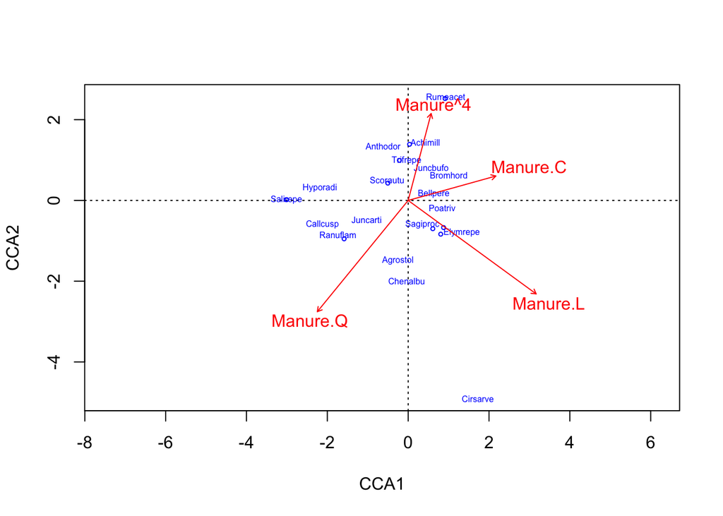

```r
plot(cca_dune_manure, type='n', scaling=1)
orditorp(cca_dune_manure, display='sp', cex=0.5, scaling=1, col='blue')
text(cca_dune_manure, display='bp', col='red')
```

3. Do your two analyses agree with one another or complement one another or do these two analyses seem to be suggesting different take home messages? Which analysis do you find to be more useful?